# Plotting and visualising data

# 3 The `ggplot2` package

**`ggplot2`** is a plotting package that makes it simple to create complex plots from data in a data frame. It provides a more programmatic interface for specifying what variables to plot, how they are displayed, and general visual properties. The theoretical foundation that supports the `ggplot2` is the *Grammar of Graphics*. Instead of producing the figure, the user defines and assembles the visual components into an object that is the displayed. There is a book about ggplot2 that provides a good overview, but it is outdated. The ggplot2 web page (https://ggplot2.tidyverse.org) provides ample documentation.

Wilkinson, Leland. 2005. The Grammar of Graphics (Statistics and Computing). Berlin, Heidelberg: Springer-Verlag.

Wickham, Hadley. 2016. ggplot2: Elegant Graphics for Data Analysis. Springer-Verlag New York.

To build a ggplot, we will use the following basic template that can be used for different types of plots:

```
ggplot(data = <DATA>, mapping = aes(<MAPPINGS>)) +  <GEOM_FUNCTION>()
```

We need first to load the `ggplot2` package:

```r
library("ggplot2")
```

- use the `ggplot()` function and bind the plot to a specific data frame using the `data` argument

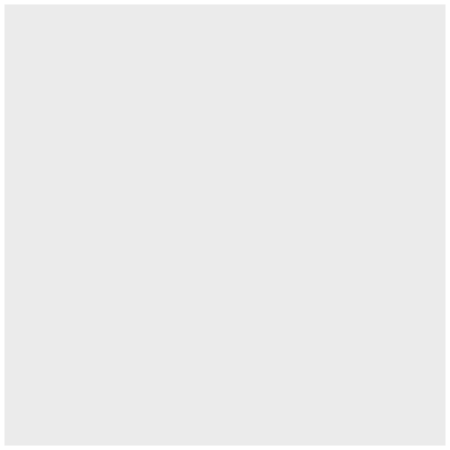

We have only specified the data, and there’s nothing to display yet.

```r
ggplot(data = DNase)
```

- define a mapping (using the aesthetic (`aes`) function), by selecting the variables to be plotted and specifying how to present them in the graph, e.g. as x/y positions or characteristics such as size, shape, colour, etc.

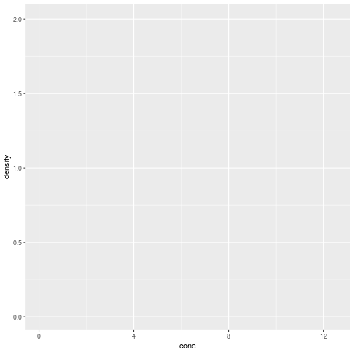

`ggplot2` can now generate the axes, ticks and ranges based on the data.

```r
ggplot(data = DNase,
       mapping = aes(x = conc, y = density))
```

- add *geoms* – graphical representations of the data in the plot (points, lines, bars). To add a geom to the plot use the `+` operator. Because we have two continuous variables, let’s use `geom_point()` first:

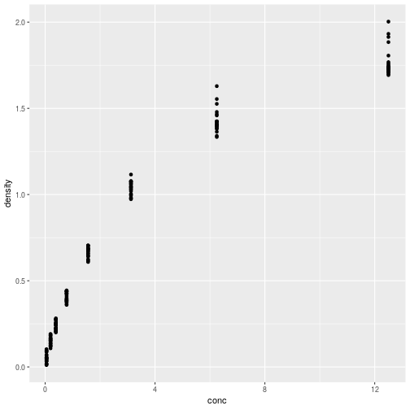

Final figures with rendering of the data as a scatter plot.

```r
ggplot(data = DNase,
       mapping = aes(x = conc, y = density)) +
  geom_point()
```

**Exercise:** compare the `ggplot2` and base graphics version of the density vs. concentration plot. Which one do you prefer, and why?

It is possible to store the output of the `ggplot` function into a variable that can be visualised by either typing its name in the console or explicitly printing it (like any other variable).

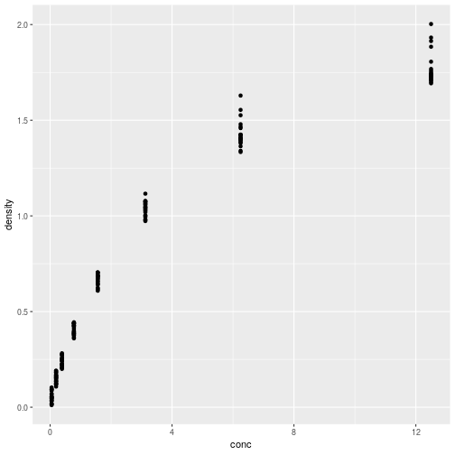

Saving and printing an object.

```r
gg <- ggplot(data = DNase,
             mapping = aes(x = conc, y = density)) +
    geom_point()
print(gg)
```

Let’s immediately customise this visualisation to - highlight how to re-use the `gg` object without repeating the plotting code and - how we can add additional (identical or different) *geoms* to a plot.

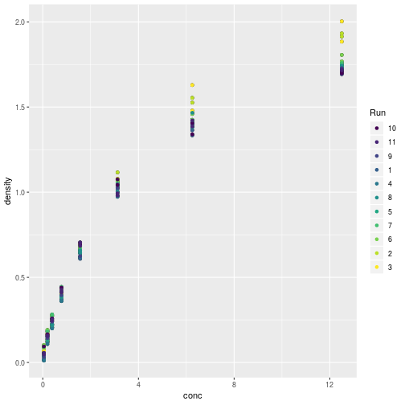

Adding another `geom_point` with its own (local) aesthetics.

```r
gg + geom_point(aes(colour = Run))
```

**Exercise:** What do you think of the colours used to differentiate the different runs above?

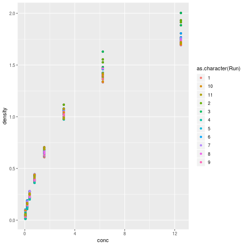

```r
gg + geom_point(aes(colour = as.character(Run)))
```

Below is an example of more elaborated composition, overlaying points and a non-linear *loess* regression. But first, let’s load a object containing microarray data from the [`hiiragi2013.rda` file](https://github.com/lgatto/visualisation/raw/master/data/hiiragi2013.rda). The data is originally available from the [`Hiiragi2013`](http://bioconductor.org/packages/release/data/experiment/html/Hiiragi2013.html) package and *Cell-to-cell expression variability followed by signal reinforcement progressively segregates early mouse lineages* paper by Y. Ohnishi *et al.* Nature Cell Biology (2014) 16(1): 27-37. [doi:10.1038/ncb2881](https://www.nature.com/articles/ncb2881).

Below, we combine the (transposed) expression values (extracted from the `hiiragi2013` object with `exprs`) and sample metadata (ext-raced from the `hiiragi2013` object with `pData`)

```r
load("./data/hiiragi2013.rda")
library("Biobase")
dftx <- data.frame(t(Biobase::exprs(hiiragi2013)), pData(hiiragi2013))
dftx[1:10, 1:3]
```

```
##          X1415670_at X1415671_at X1415672_at
## 1 E3.25     4.910459    9.768979   10.411893
## 2 E3.25     7.526672    9.144228   10.918942
## 3 E3.25     6.956328    9.295010    9.495738
## 4 E3.25     6.424048   11.059831   10.317996
## 5 E3.25     5.105808    9.376749   11.143684
## 6 E3.25     5.856685    9.681017   10.234943
## 7 E3.25     5.059961    7.665886   10.642970
## 8 E3.25     4.574661    9.325743    9.304958
## 9 E3.25     8.123073    9.724729   11.037632
## 10 E3.25    5.464257    9.389818    9.754123
```

```r
dftx[1:10, 45105:45109]
```

```
##          lineage genotype   ScanDate sampleGroup sampleColour
## 1 E3.25                WT 2011-03-16       E3.25      #CAB2D6
## 2 E3.25                WT 2011-03-16       E3.25      #CAB2D6
## 3 E3.25                WT 2011-03-16       E3.25      #CAB2D6
## 4 E3.25                WT 2011-03-16       E3.25      #CAB2D6
## 5 E3.25                WT 2011-03-16       E3.25      #CAB2D6
## 6 E3.25                WT 2011-03-16       E3.25      #CAB2D6
## 7 E3.25                WT 2011-03-16       E3.25      #CAB2D6
## 8 E3.25                WT 2011-03-16       E3.25      #CAB2D6
## 9 E3.25                WT 2011-03-16       E3.25      #CAB2D6
## 10 E3.25               WT 2011-03-16       E3.25      #CAB2D6
```

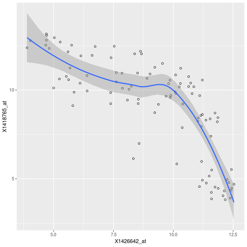

Modelling the relation between the expression of X1426642_at and X1418765_at.

```r
ggplot(dftx, aes(x = X1426642_at, y = X1418765_at)) +
    geom_point(shape = 1) +
    geom_smooth(method = "loess")
```

And, adding colours representing the different samples

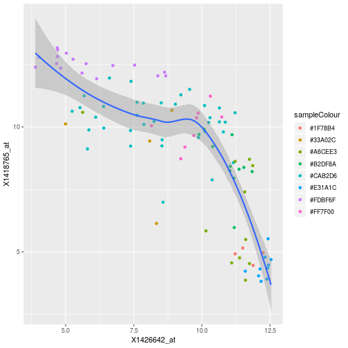

Modelling the relation between the expression of X1426642_at and X1418765_at and annotating samples.

```r
ggplot(dftx, aes(x = X1426642_at, y = X1418765_at))  +
  geom_point(aes(color = sampleColour), shape = 19) +
  geom_smooth(method = "loess")
```

# 4 Visualising 1D data

Let’s start by exploring some 1 dimensional visualisation. This is very relevant for omics data such as transcriptomics or quantitative proteomics, when contrasting the expression values across multiple samples.

First, we convert a microarray gene expression data to a data.frame, fit for some `ggplot2` visualisation, focusing on genes Fgf4, Gata4, Gata6 and Sox2.

```r
selectedProbes <- c(Fgf4 = "1420085_at", Gata4 = "1418863_at",
                    Gata6 = "1425463_at",  Sox2 = "1416967_at")
```

```r
library("dplyr")
library("tidyr")
tmp <- data.frame(t(exprs(hiiragi2013[selectedProbes, ])))
names(tmp) <- names(selectedProbes)
tmp$sample <- rownames(tmp)
head(tmp)
```

```
##              Fgf4    Gata4    Gata6     Sox2  sample
## 1 E3.25  3.027715 4.843137 5.500618 1.731217 1 E3.25
## 2 E3.25  9.293016 5.530016 6.160900 9.697038 2 E3.25
## 3 E3.25  2.940142 4.418059 4.584961 4.161240 3 E3.25
## 4 E3.25  9.715243 5.982314 4.753439 9.540123 4 E3.25
## 5 E3.25  8.924228 4.923580 4.629728 8.705340 5 E3.25
## 6 E3.25 11.325952 4.068520 4.165692 8.696228 6 E3.25
```

```r
genes <- gather(tmp, key = "gene", value = "expression", -sample)
head(genes)
```

```
##    sample gene expression
## 1 1 E3.25 Fgf4   3.027715
## 2 2 E3.25 Fgf4   9.293016
## 3 3 E3.25 Fgf4   2.940142
## 4 4 E3.25 Fgf4   9.715243
## 5 5 E3.25 Fgf4   8.924228
## 6 6 E3.25 Fgf4  11.325952
```

## 4.1 Histogram

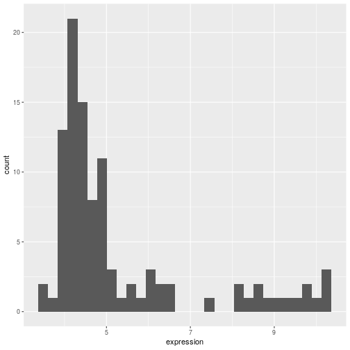

Distribution of the Gata4 expression

```r
genes %>%
    filter(gene == "Gata4") %>%
    ggplot(aes(x = expression)) + geom_histogram()
```

## 4.2 Box plots

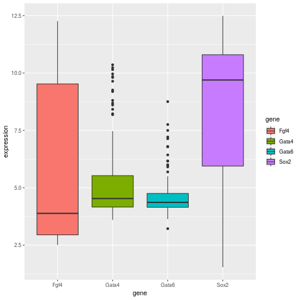

A boxplot of expression values.

```r
p <- ggplot(genes, aes(x = gene, y = expression, fill = gene))
bxplot <- p + geom_boxplot()
bxplot
```

**Exercise:** Repeat the above figure replacing the boxes by violins using the `geom_violin`. Which one do you think does a better job?

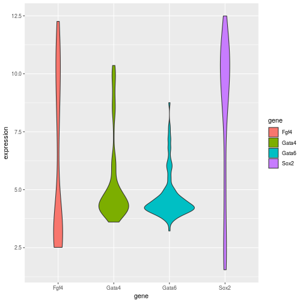

```r
vlnplot <- p + geom_violin()
vlnplot
```

## 4.3 Dot plots and beeswarm plots

When the data aren’t too large, it is also possibly to visualise all points to get a sense of their distribution.

```r
jtrplot <- p +
    geom_jitter(aes(colour = gene)) +
    theme(legend.position = "none")
```

In a dotplot, the position of the points along the y axis is discretised into bins (set as 1/6 below) and the points are then stacked next to each other.

```r
dotplot <- p + geom_dotplot(binaxis = "y", binwidth = 1/6,
                            stackdir = "center", stackratio = 0.75,
                            aes(color = gene)) +
    theme(legend.position = "none")
```

The beeswarm algorithms tries to avoid overlapping points.

```r
library("ggbeeswarm")
beeplot <- p + geom_beeswarm(aes(color = gene)) +
    theme(legend.position = "none")
```

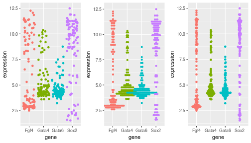

Showing all expression values using jittering (left), a dotplot (centre) and a beeswarn plot.

```r
library(patchwork)
jtrplot + dotplot + beeplot
```

## 4.4 Density and ecdf plots

```r
densplot <- ggplot(genes, aes(x = expression, color = gene)) +
    geom_density() +
    theme(legend.position = "none")
```

```r
ecdfplot <- ggplot(genes, aes(x = expression, color = gene)) +
    stat_ecdf() +
    theme(legend.position = "none")
```

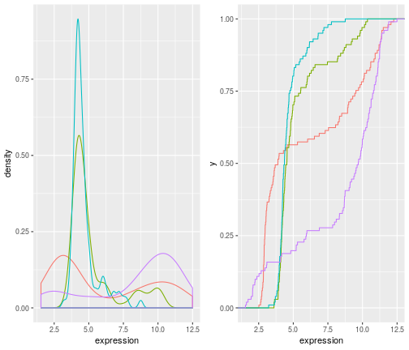

Density and cumulative density functions of expression values.

```r
densplot + ecdfplot
```

## 4.5 Summary

- **Boxplot** makes sense for unimodal distributions (see below).
- **Histogram** requires definition of bins (width, positions) and can create visual artefacts especially if the number of data points is not large.
- **Density** requires the choice of bandwidth; obscures the sample size (i.e. the uncertainty of the estimate).
- **ecdf** does not have these problems; but is more abstract and interpretation requires more training. Good for reading off quantiles and shifts in location in comparative plots.
- **beeswarm**: for up to a few dozens of points, just show the data.

The number of modes of a distribution depends on scale transformation of the data.

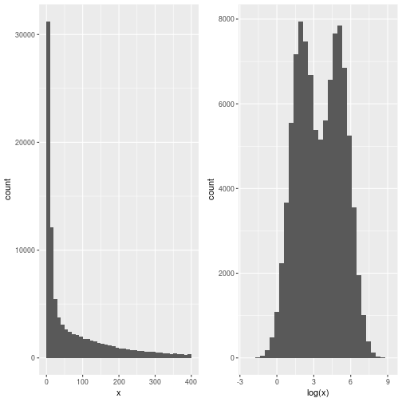

Histograms of the same data without (left) and with (right) log-transformation.

```r
sim <- data.frame(x = exp(rnorm(n = 1e5,
                                mean = sample(c(2, 5),
                                              size = 1e5,
                                              replace = TRUE))))

p1 <-  ggplot(sim, aes(x)) +
    geom_histogram(binwidth = 10, boundary = 0) +
    xlim(0, 400)
p2 <-  ggplot(sim, aes(log(x))) +
    geom_histogram(bins = 30)
p1 + p2
```

This also applies to density plots.

# 5 Visualising 2D data

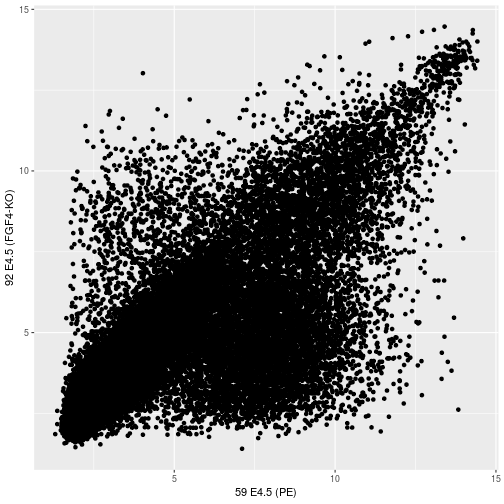

Scatter plot comparing the expression of a wild-type vs. FGF4 KO.

```r
dfx <- as.data.frame(Biobase::exprs(hiiragi2013))
scp <- ggplot(dfx, aes(x= `59 E4.5 (PE)`,
                       y = `92 E4.5 (FGF4-KO)`))
scp + geom_point()
```

**Exercise:** The over-plotting of the dots stops us from learning anything about the density of the different regions of the plot. Use the `alpha` parameter to `geom_points` between 0 (full transparency) to 1 (opaque, default).

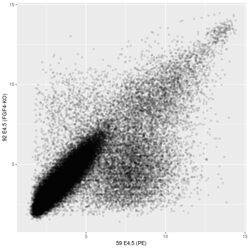

```r
scp + geom_point(alpha = 0.1)
```

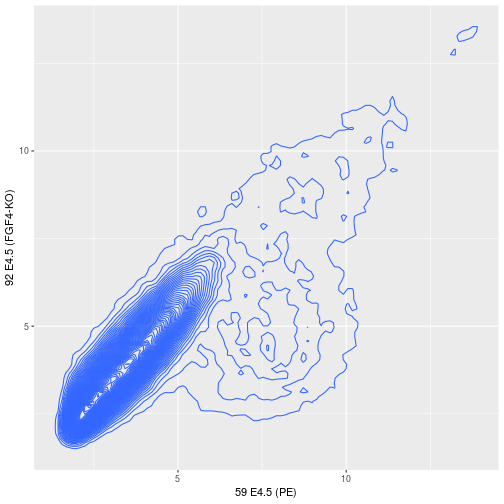

Focusing on contours rather that individual values.

```r
scp + geom_density2d(h = 0.5, bins = 60)
```

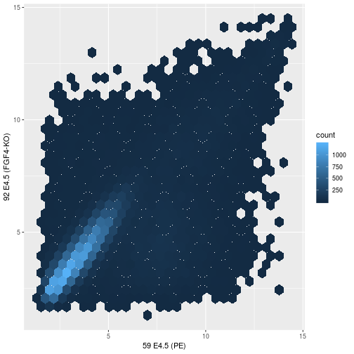

Local density summaries.

```r
scp + geom_hex()
```

# 6 Visualising data along more dimensions

When visualising data along additional dimension, we can parameterise the points by setting their shape, colour, size and transparency, that can be set with point aesthetics such as `fill`, `color` (or `colour`), `shape`, `size` and `alpha`.

A very powerful way to represent data along additional dimensions is facetting, i.e. producing sub-plots for different subsets of the data. Below, we first re-annotate the data using some regular expressions

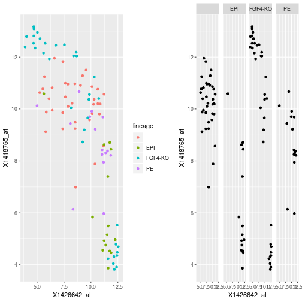

Different sub-plots for different lineages using colours (left) of facets(right) to distinguish the different lineages.

```r
p1 <- ggplot(dftx, aes(x = X1426642_at, y = X1418765_at, colour = lineage)) +
  geom_point()
p2 <- ggplot(dftx, aes(x = X1426642_at, y = X1418765_at)) +
  geom_point() +
    facet_grid( . ~ lineage )
p1 + p2
```

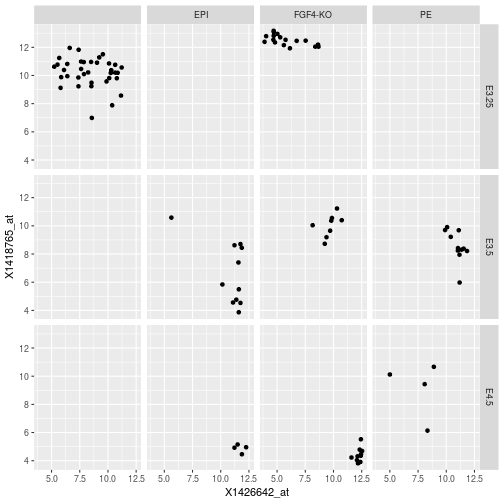

Different sub-plots for different lineages and embryonic stages.

```r
ggplot(dftx,
       aes(x = X1426642_at, y = X1418765_at)) +
    geom_point() +
    facet_grid( Embryonic.day ~ lineage )
```

**Exercise:** Use facets to visualise the distribution of the four Fgf4, Gata4, Gata6 and Sox2 genes in the `genes` data using histograms.

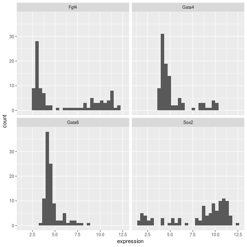

```r
ggplot(genes, aes(x = expression)) +
    geom_histogram() +
    facet_wrap(~ gene)
```

# 7 Interactive visualisation

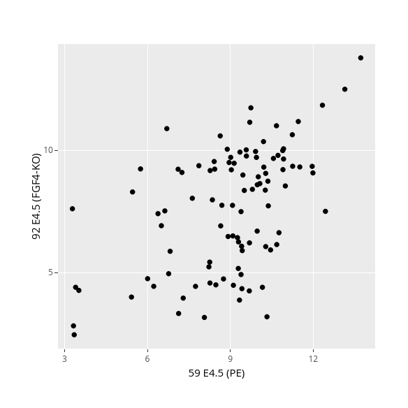

Interactive visualisation with plotly

```r
library("plotly")

scp <- ggplot(dfx[1:100, ],
              aes(x= `59 E4.5 (PE)`, y = `92 E4.5 (FGF4-KO)`))

scp2 <- scp + geom_point()
ggplotly(scp2)
```

See https://plot.ly/r for examples of interactive graphics online.